# Análise descritiva - myopia database

Aline Cristina Pinto (2020031412) e Sofia Aguiar (2020031811)

### Gráficos

**Gráfico 1 - Proporção de sujeitos míopes e não míopes no estudo**

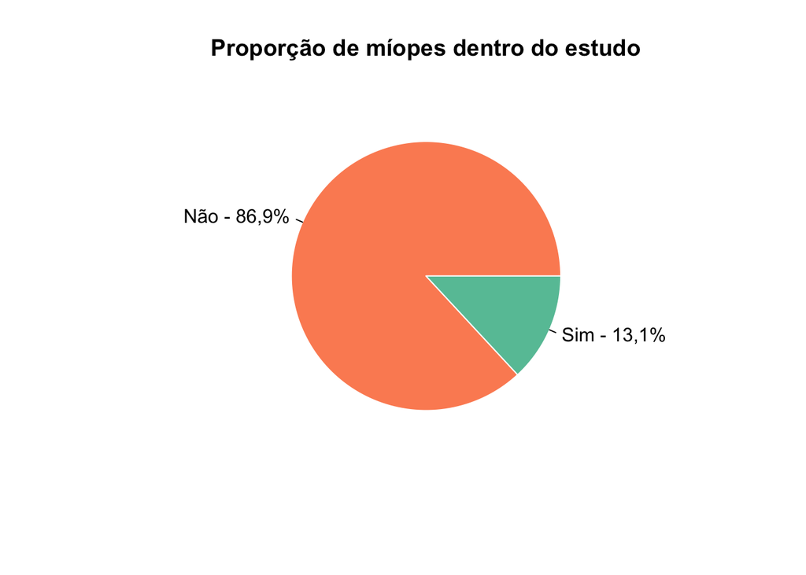

O estudo acompanhou 618 crianças entre 5 e 9 anos para coletar dados sobre o desenvolvimento da miopia. Dentro das pessoas acompanhadas pelo estudo apenas 13,1% foram diagnosticadas como míopes na primeira consulta ou nos cinco anos seguintes, enquanto seus hábitos e informações clínicas foram monitorados.

**Gráfico 2 - Comparação entre horas de leitura semanais entre sujeitos míopes e não-míopes**

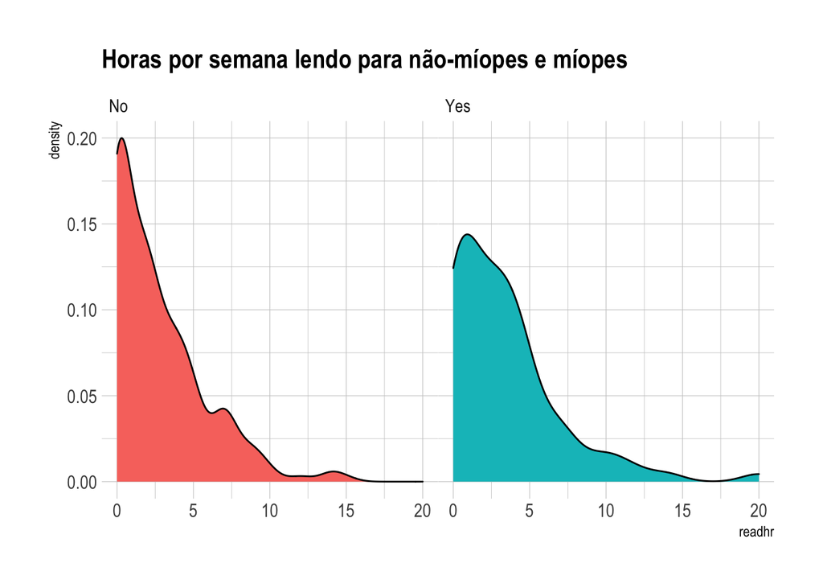

Para comparar as observações das pessoas com e sem miopia devemos comparar as distribuições e não as observações pela diferença de tamanho nas amostras. O gráfico acima compara as distribuições das horas gastas lendo no intervalo de uma semana divididos entre míopes e não míopes. Podemos visualizar pela comparação que os míopes passam mais tempo lendo que seus contrapartes de visão normal.

**Gráfico 3 - Comparação entre horas assistindo televisão em uma semana entre sujeitos míopes e não-míopes**

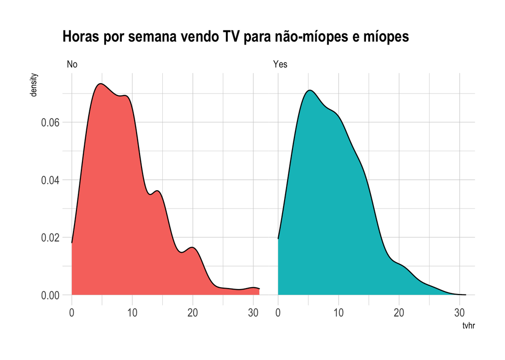

**Gráfico 4 - Comparação entre horas de atividades similares a trabalho em uma semana entre sujeitos míopes e não-míopes**

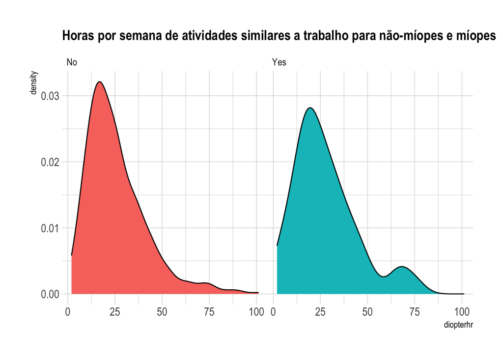

O gráfico acima compara as distribuições das horas gastas fazendo atividades similares a trabalho no intervalo de uma semana divididos entre míopes e não míopes. Da mesma forma que nos gráficos anteriores, podemos observar que os míopes passam mais tempo desempenhando tais atividades do que seus contrapartes de visão normal, já que sua distribuição é mais concentrada à direita do que no gráfico dos não-míopes.

**Gráfico 5 - Gráfico para a frequência das idades dos sujeitos do estudo em sua primeira consulta**

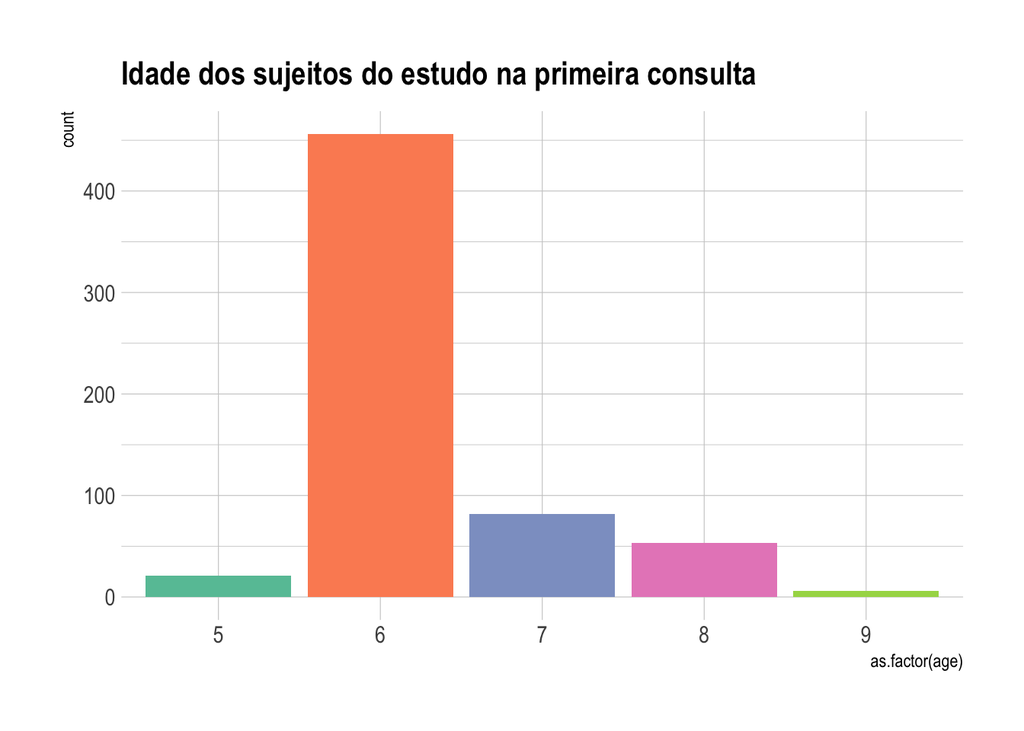

O gráfico acima mostra a frequência da idade dos sujeitos no início do estudo, evidenciando que a maior parte das pessoas são crianças de 6 anos e que, ao final do estudo, tinham 11 anos. Essa é a faixa etária onde é ais frequente o diagnóstico de miopia, apesar de que ela pode se desenvolver em qualquer idade.

### Tabelas

**Tabela 1 - Relação entre pais, filhos e miopia**

Relação entre pais, filhos e miopia

| Criança | Pais com miopia (%) Ambos | Pais com miopia (%) Apenas mãe | Pais com miopia (%) Apenas pai | Pais com miopia (%) Nenhum |
| --- | --- | --- | --- | --- |
| Míope | 43.21 | 24.69 | 25.93 | 6.17 |
| Não míope | 22.35 | 25.70 | 24.58 | 27.37 |

A *Tabela 1 - Relação entre pais, filhos e miopia* foi criada a partir das variáveis myopic, mommy e dadmy, e busca mostrar, através de uma tabela de frequência relativa, a proporção de crianças míopes e não míopes e a condição de seus pais.

Pode-se observar que para crianças que possuem miopia, apenas 6% dos pais não possuem essa condição óptica. Já para as crianças que não possuem miopia, essa proporção é quase igualmente distribuída entre as opções de ambos os pais possuírem miopia, apenas a mãe, apenas o pai ou nenhum deles possuírem essa condição óptica.

**Tabela 2 - Condição de miopia das crianças por sexo**

Condição de miopia das crianças por sexo

| Masculino | Feminino |
| --- | --- |
| 45.47 | 41.42 |
| 5.66 | 7.44 |

A *Tabela 2 - Condição de miopia das crianças por sexo* foi criada a partir das variáveis myopic e gender, e busca mostrar, através de uma tabela de frequência relativa, a proporção de crianças míopes e não míopes pelo sexo.

Pode-se observar que a maioria das crianças, independente do sexo, não possuem miopia. Ainda, a proporção de crianças do sexo feminino que possuem miopia é maior do que as crianças do sexo masculino, porém essa diferença é muito pequena.

### Sobre

**Pacote:** Aplore 3

**Banco de dados:** myopia

myopia faz parte de um conjunto de dados da Orinda Longitudinal Study of Myopia (OLSM), um estudo sobre o desenvolvimento do componente ocular e fatores de risco para o início da miopia em crianças.

A coleta de dados desse database foi iniciada durante o período escolar de 1989–1990 e continuou anualmente até o ano escolar de 2000–2001 e contém não só dados sobre a criança, mas também aspectos familiares. Os dados sobre as partes que compõem o olho da criança (os componentes oculares) foram coletados durante exames em um dia escolar. Sobre a história familiar e atividades visuais, os dados foram coletados anualmente em uma pesquisa respondida por um dos pais ou responsável.

**Variáveis:**

**id:** Identificador de sujeito

**studyyear:** Ano que entrou no estudo

**myopic:** Se foi diagnosticado como míope nos cinco anos de acompanhamento

**age:** Idade em anos na primeira visita

**gender:** Sexo (Masculino ou Feminino)

**spheq:** Refração equivalente esférica (dioptria)

**al:** Comprimento axial (mm)

**acd:** Profundidade da Câmara Anterior (mm)

**lt:** Espessura da lente (mm)

**vcd:** Profundidade da câmara vítrea (mm)

**sporthr:** Horas por semana praticando esportes fora da escola

**readhr:** Horas por semana lendo fora da escola **comphr:** Horas por semana usando computador fora da escola **studyhr:** Horas por semana estudando fora da escola **tvhr:** Horas por semana vendo televisão fora da escola **diopterhr** Compósito de horas por semana praticando atividades similares a trabalho fora da escola **mommy** Se a mãe do sujeito é míope **dadmy** Se o pai do sujeito é míope